# Data visualization with ggplot2

Day 2 - Introduction to Data Analysis with R

Selina Baldauf

Freie Universität Berlin - Theoretical Ecology

October 17, 2026

# A ggplot showcase

> Example plots you can create with ggplot

## A ggplot showcase

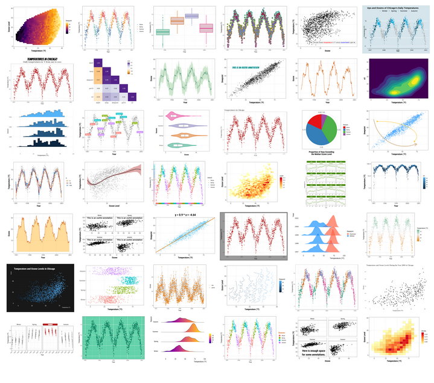

Overview of different plot possibilites created by Cédric Scherer. Check out [his tutorial](https://cedricscherer.netlify.app/2019/08/05/a-ggplot2-tutorial-for-beautiful-plotting-in-r/#toc) to learn how to make all these plots with ggplot

## A ggplot showcase

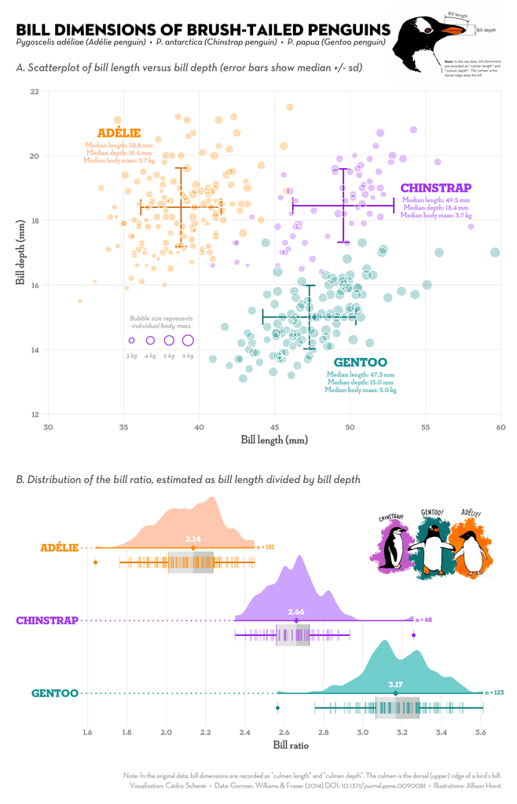

Visualization by [Cédric Scherer](https://twitter.com/CedScherer), code available on [Github](https://github.com/z3tt/TidyTuesday/blob/master/R/2020_31_PalmerPenguins.Rmd)

## The ggplot2 package

- **Consistent** grammar/structure
- **Flexible** structure allows you to produce any type of plots
- Highly **customizable appearance** (themes)
- Many **extension packages** that provide additional plot types, themes, colors, animation, …
  - See [here](https://exts.ggplot2.tidyverse.org/gallery/) for a list of ggplot extensions
- Active community that provides help and inspiration
- Perfect package for **exploratory data analysis** and **beautiful plots**

Part of the tidyverse

```r
library(tidyverse)
# Or load it individually:
# library(ggplot2)
```

## The data

The `gapminder` dataset contains data on life expectancy, GDP per capita, and population for 142 countries from 1952 to 2007.

```r
# install.packages("gapminder")
library(gapminder)
gapminder
```

```
#> # A tibble: 1,704 × 6
#>    country     continent  year lifeExp      pop gdpPercap
#>    <fct>       <fct>     <int>   <dbl>    <int>     <dbl>
#>  1 Afghanistan Asia       1952    28.8  8425333      779.
#>  2 Afghanistan Asia       1957    30.3  9240934      821.
#>  3 Afghanistan Asia       1962    32.0 10267083      853.
#>  4 Afghanistan Asia       1967    34.0 11537966      836.
#>  5 Afghanistan Asia       1972    36.1 13079460      740.
#>  6 Afghanistan Asia       1977    38.4 14880372      786.
#>  7 Afghanistan Asia       1982    39.9 12881816      978.
#>  8 Afghanistan Asia       1987    40.8 13867957      852.
#>  9 Afghanistan Asia       1992    41.7 16317921      649.
#> 10 Afghanistan Asia       1997    41.8 22227415      635.
#> # ℹ 1,694 more rows
```

```r
gapminder_2007 <- filter(gapminder, year == 2007)
```

How is life expectancy related to GDP per capita?

# Building a ggplot

> Step by step

## Step 1: `ggplot(data)`

The `ggplot()` function initializes a ggplot object. Every ggplot needs this function.

```r
ggplot(gapminder_2007)
```

- Empty plot because we haven’t told ggplot what to put on the axes yet

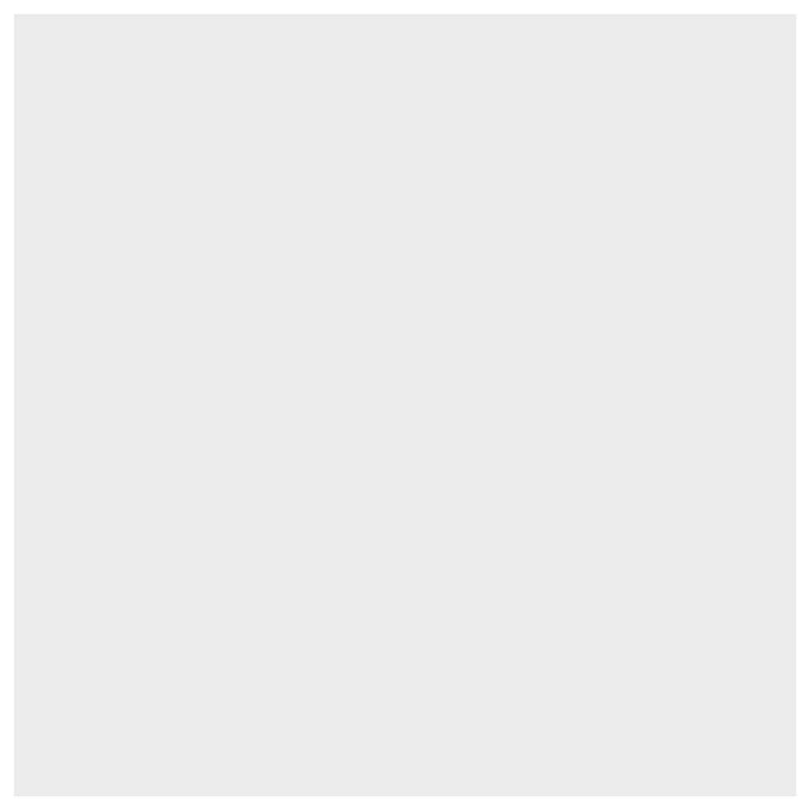

## Step 2: add `aes(x, y)`

The **aes**thetics define how data variables are mapped to plot properties.

```r
ggplot(
  gapminder_2007,
  aes(
    x = gdpPercap,
    y = lifeExp
  )
)
```

- Axes are set up, but no data points yet
- Scales adapt automatically to the range of the data

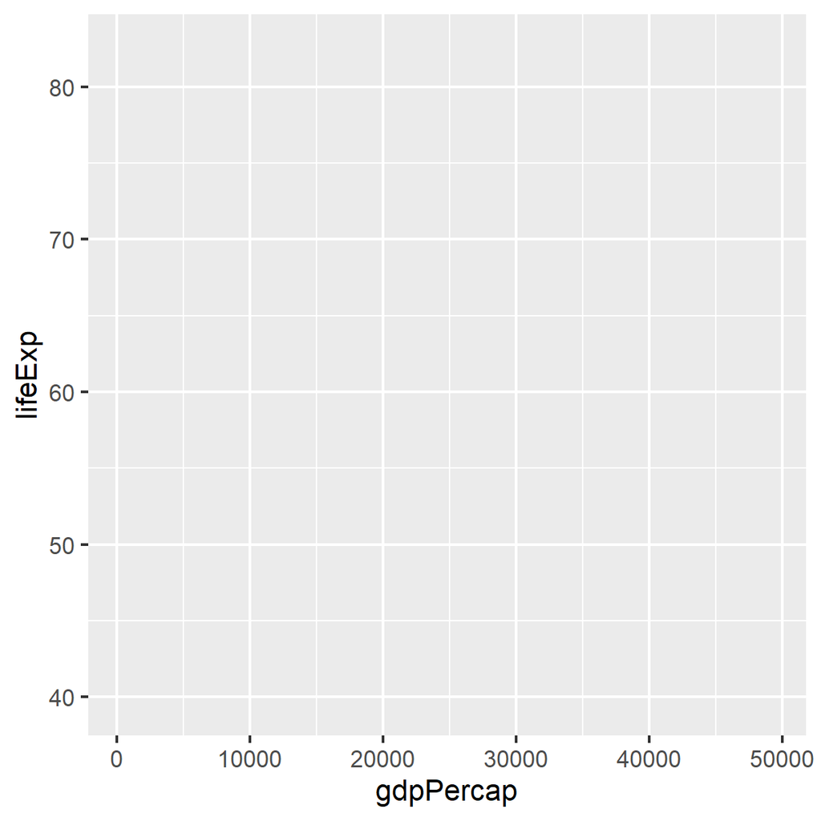

## Step 3: add a `geom`

`geoms` define how data points are represented. There are many different geoms to chose from

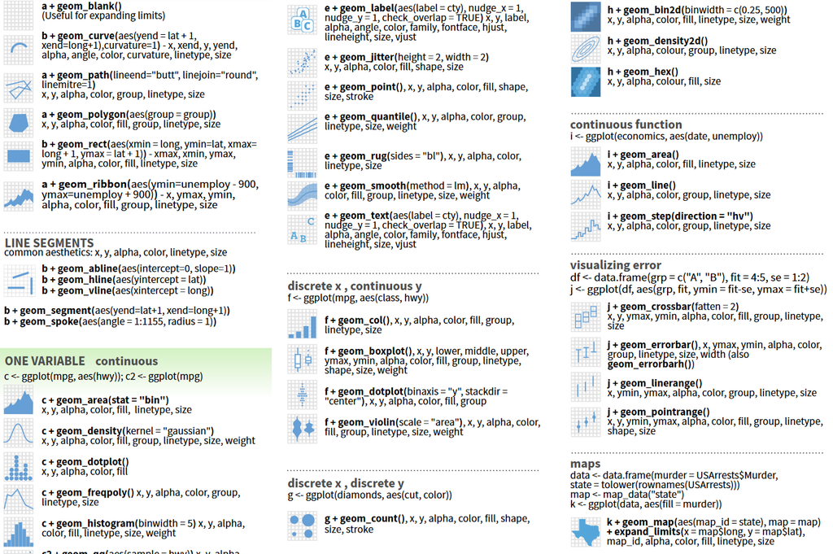

from [ggplot cheatsheet](https://raw.githubusercontent.com/rstudio/cheatsheets/master/data-visualization-2.1.pdf)

## Step 3: add a `geom`

```r
ggplot(
  gapminder_2007,
  aes(
    x = gdpPercap,
    y = lifeExp
  )
) +
  geom_point()
```

- New layers are added with `+`
- `data` and `aes` defined in `ggplot` call are inherited to all plot layers

Does this depend on the continent?

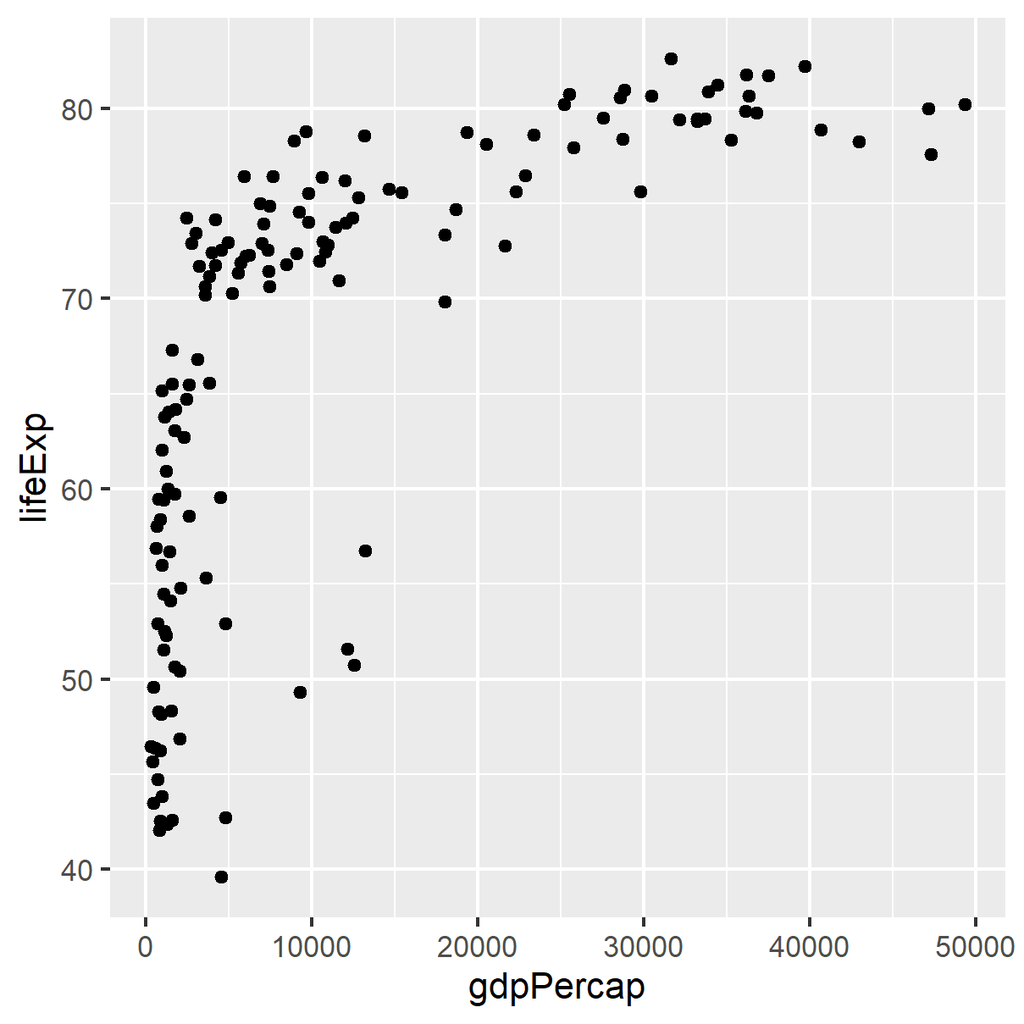

## Add color: `aes(color = ...)`

Map a variable to the **color** aesthetic to distinguish groups:

```r
ggplot(
  gapminder_2007,
  aes(
    x = gdpPercap,
    y = lifeExp,
    color = continent
  )
) +
  geom_point()
```

- `color = continent` maps the continent to point color
- A legend is added automatically

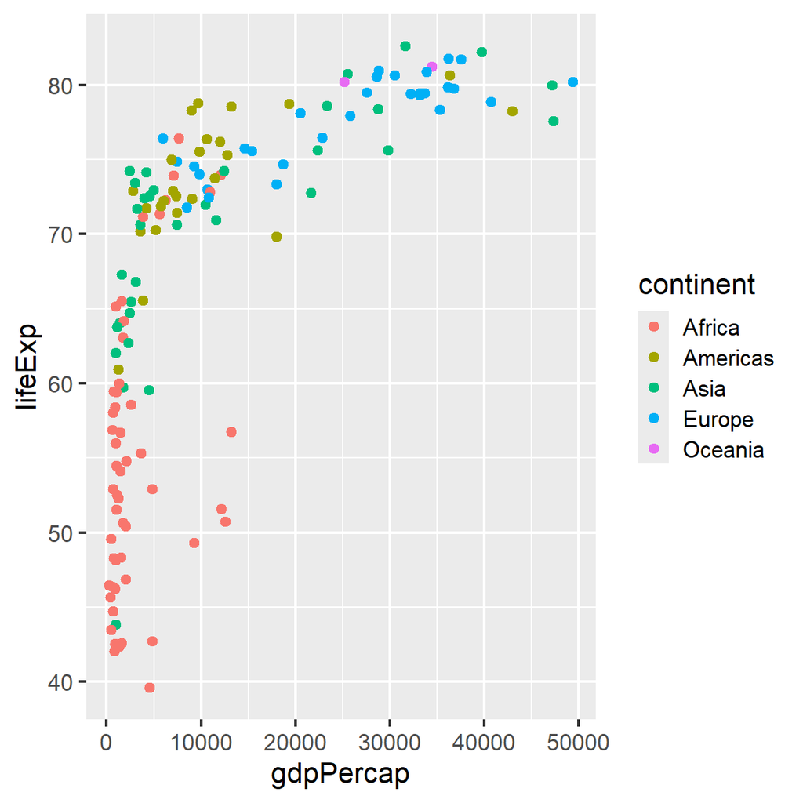

## Other aesthetics: `size`

Besides `color`, you can also map variables to `size`:

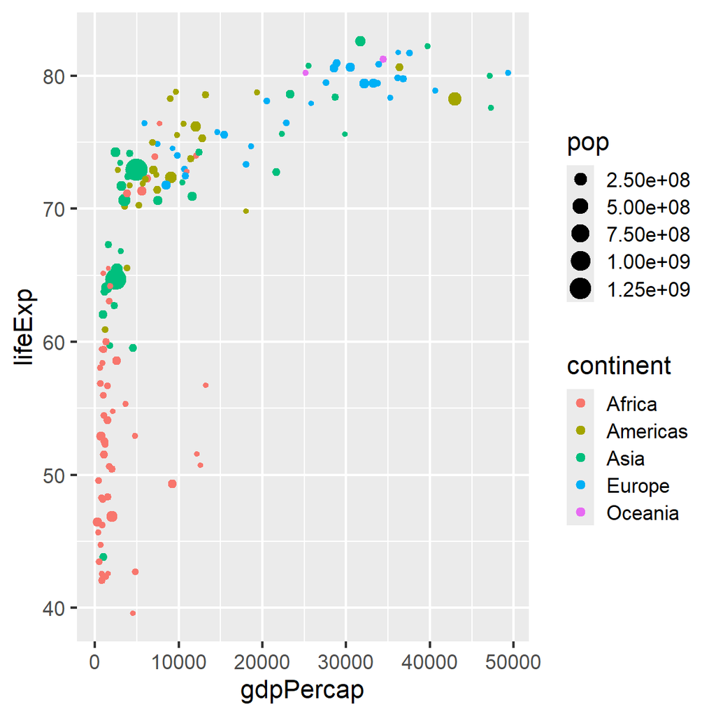

```r
ggplot(
  gapminder_2007,
  aes(
    x = gdpPercap,
    y = lifeExp,
    color = continent,
    size = pop
  )
) +
  geom_point()
```

## Other aesthetics: `shape`

Besides `color`, you can also map variables to `shape`:

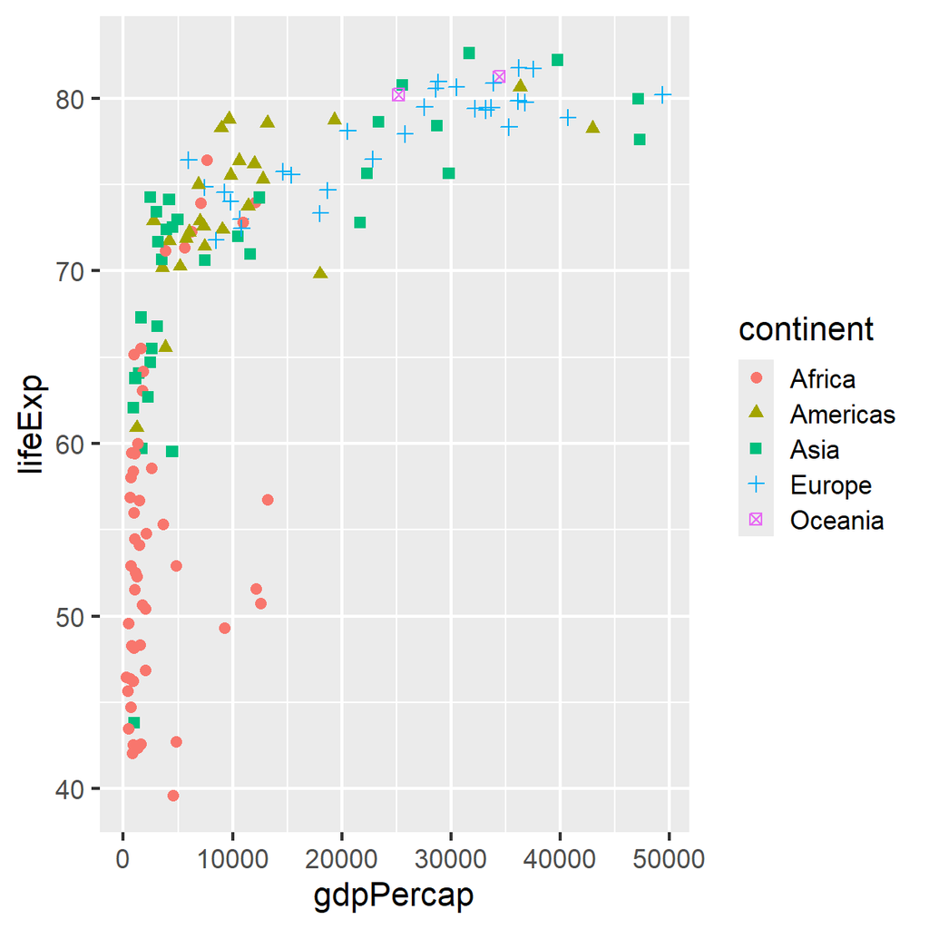

```r
ggplot(
  gapminder_2007,
  aes(
    x = gdpPercap,
    y = lifeExp,
    color = continent,
    shape = continent
  )
) +
  geom_point()
```

## Changing the scales of the aesthetics

The scales onto which the aesthetic elements are mapped can be changed.

```r
ggplot(
  gapminder_2007,
  aes(
    x = gdpPercap,
    y = lifeExp,
    color = continent
  )
) +
  geom_point()
```

- GDP is condensed on the left (few large values)
- A log scale would spread the data out

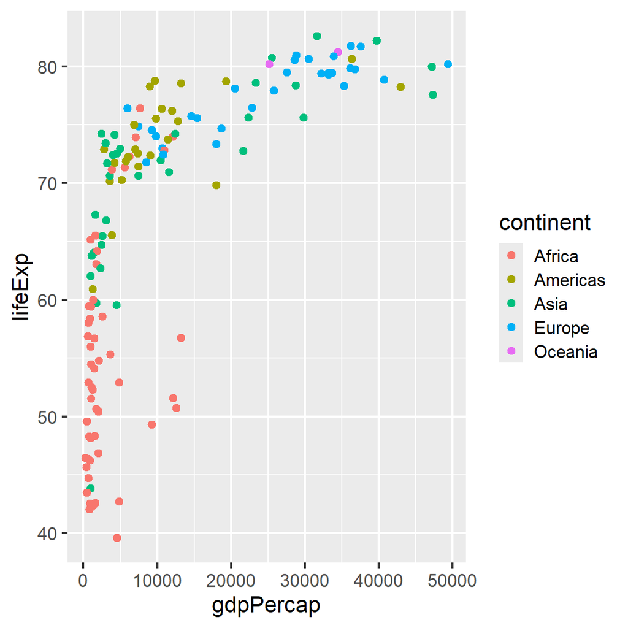

## `scale_x_log10`

```r
ggplot(
  gapminder_2007,
  aes(
    x = gdpPercap,
    y = lifeExp,
    color = continent
  )
) +
  geom_point() +
  scale_x_log10()
```

- Scales can be changed for all elements of `aes`:

`scale_aes-name_scale-type`

Here we scale the **x** aesthetic to **log10**.

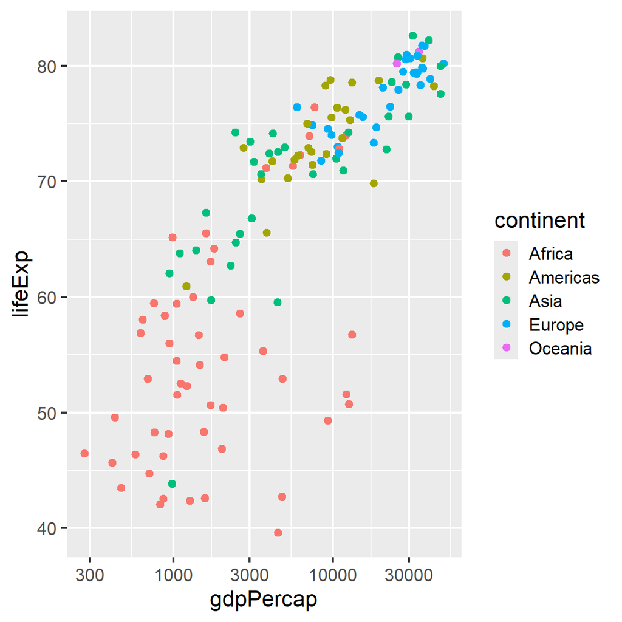

## `geom_smooth`

Add a smoothing line that helps see patterns in the data

```r
ggplot(
  gapminder_2007,
  aes(
    x = gdpPercap,
    y = lifeExp,
    color = continent
  )
) +
  geom_point() +
  geom_smooth(method = "lm") +
  scale_x_log10()
```

- With `method = "lm"`, a linear regression line is added
- All geoms done separately for each continent because color is defined globally

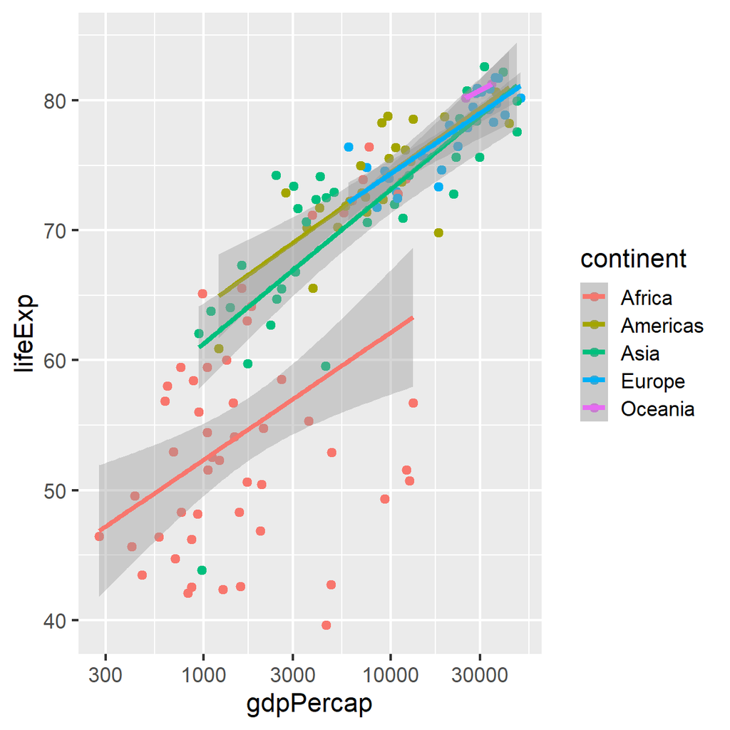

## `geom_boxplot`

Compare a numeric variable across groups:

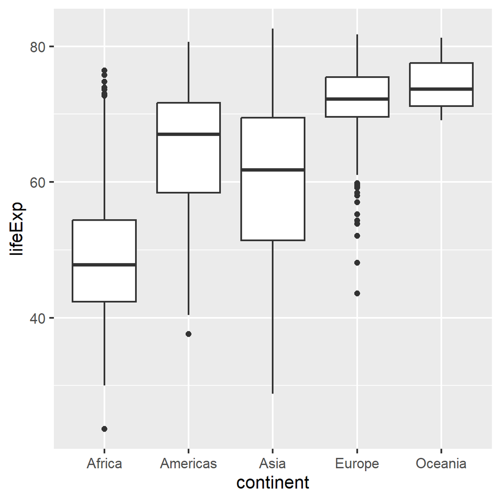

```r
ggplot(
  gapminder,
  aes(
    x = continent,
    y = lifeExp
  )
) +
  geom_boxplot()
```

## `geom_boxplot`

Compare a numeric variable across groups:

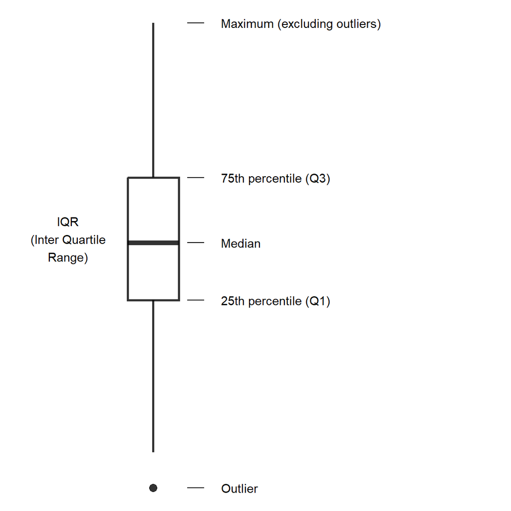

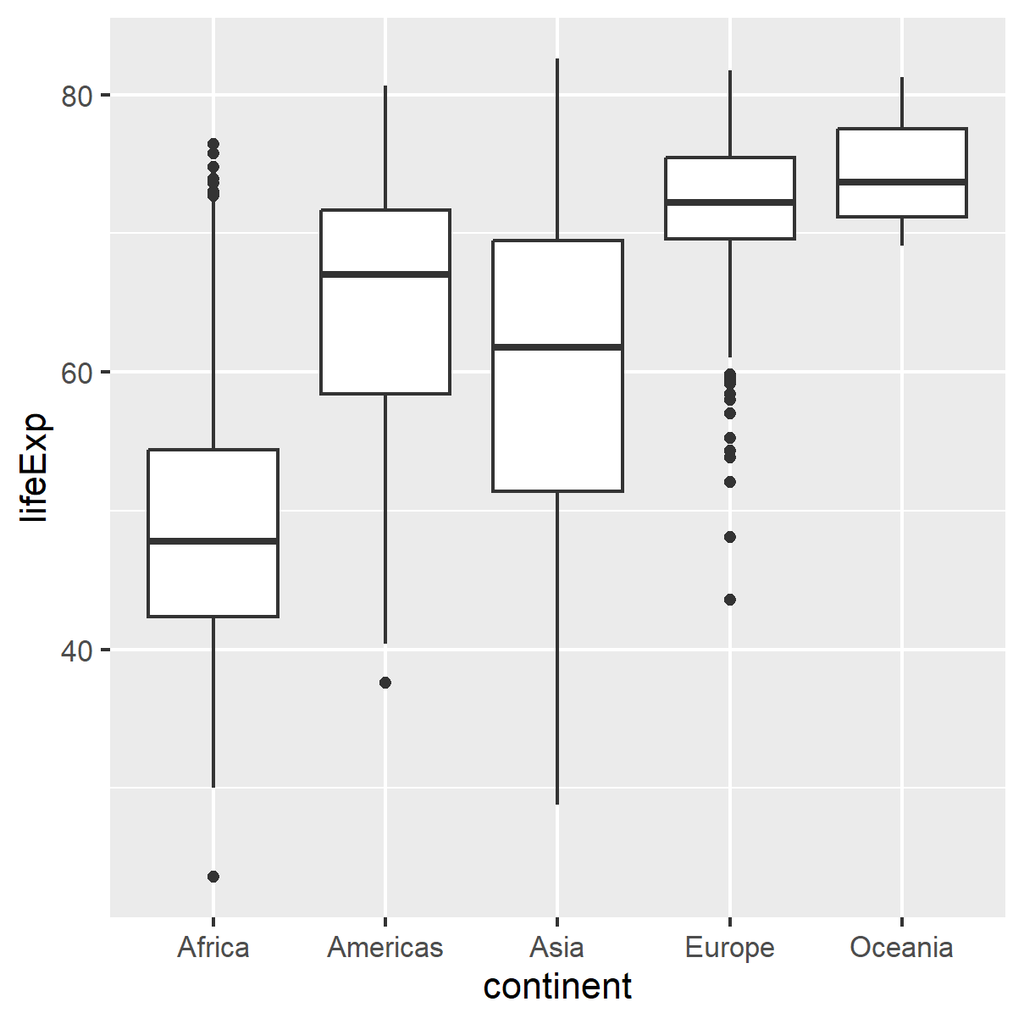

## `geom_boxplot` with color or fill

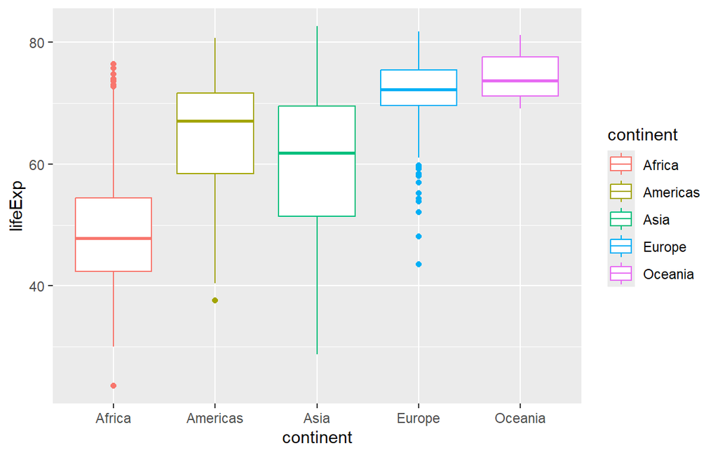

```r
ggplot(
  gapminder,
  aes(
    x = continent,
    y = lifeExp,
    color = continent
  )
) +
  geom_boxplot()
```

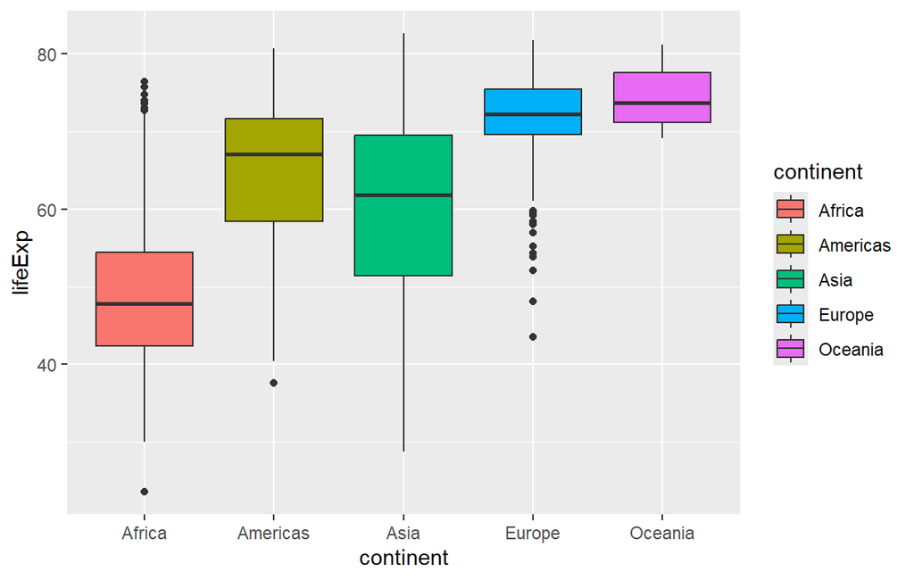

```r
ggplot(
  gapminder,
  aes(
    x = continent,
    y = lifeExp,
    fill = continent
  )
) +
  geom_boxplot()
```

## `geom_histogram`

See the distribution of a single numeric variable:

```r
ggplot(
  gapminder,
  aes(x = lifeExp)
) +
  geom_histogram()
```

- ggplot counts the observations for you (y-axis)

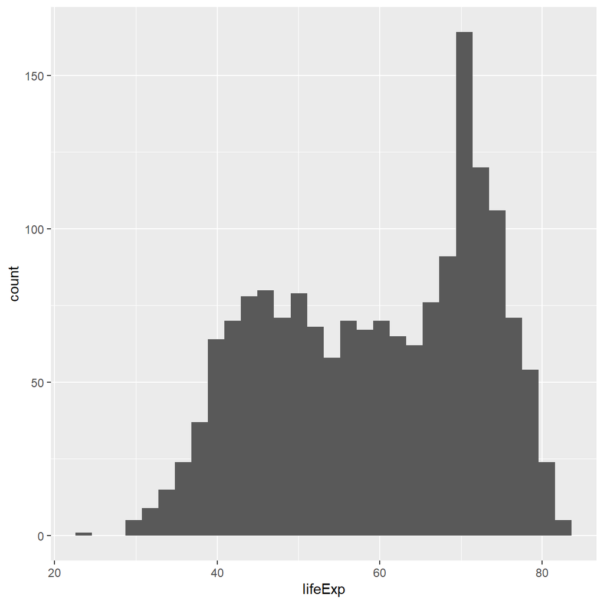

## `geom_histogram` with groups

```r
ggplot(
  gapminder,
  aes(
    x = lifeExp,
    fill = continent
  )
) +
  geom_histogram(
    position = "identity",
    alpha = 0.5
  )
```

- By default histograms are stacked
- Use `position = "identity"` to overlap them
- `alpha` makes sure you see overlapping areas
- Here it’s a bit too crowded to see differences between continents

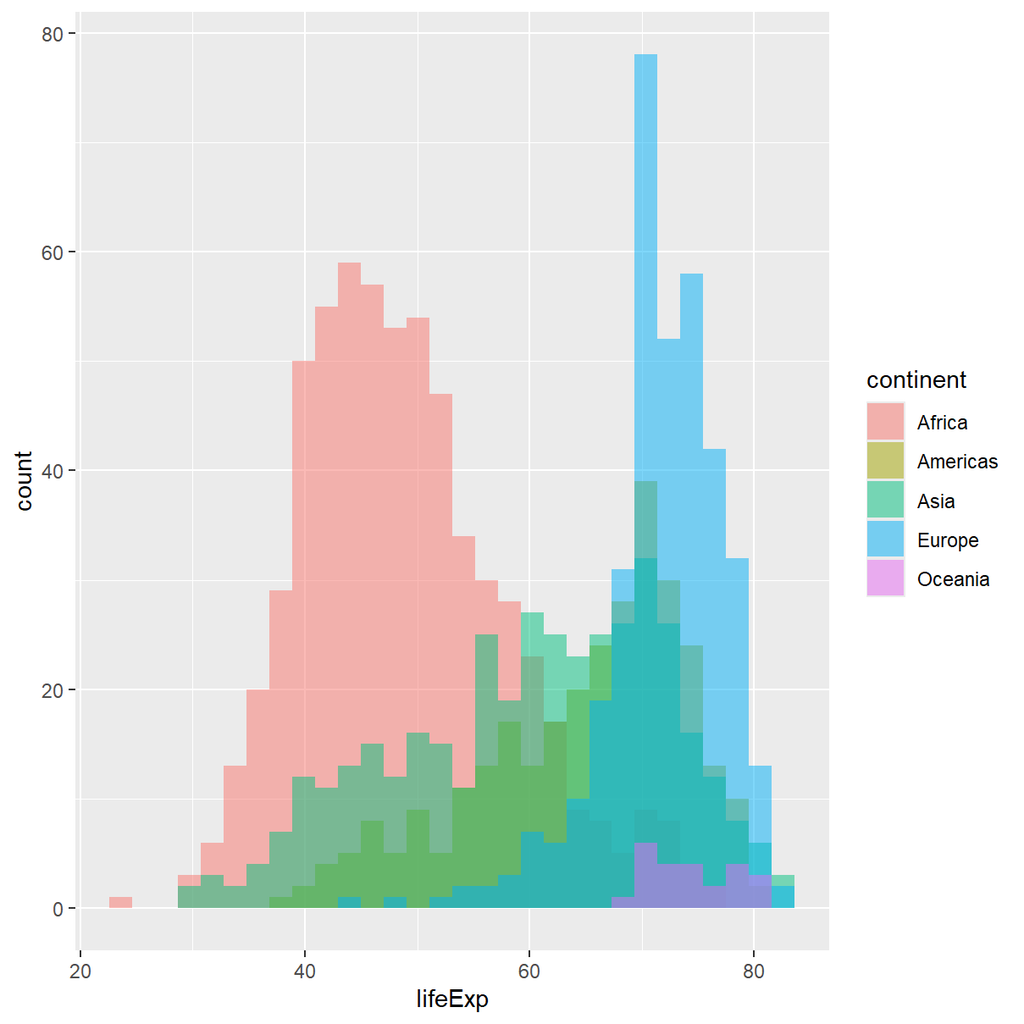

## Small multiples with `facet_wrap`

Split your plots along one variable with `facet_wrap`

```r
ggplot(
  gapminder,
  aes(
    x = lifeExp,
    fill = continent
  )
) +
  geom_histogram() +
  facet_wrap(vars(continent))
```

- Especially useful when color/shape gets crowded
- Use `facet_grid()` to split along two variables

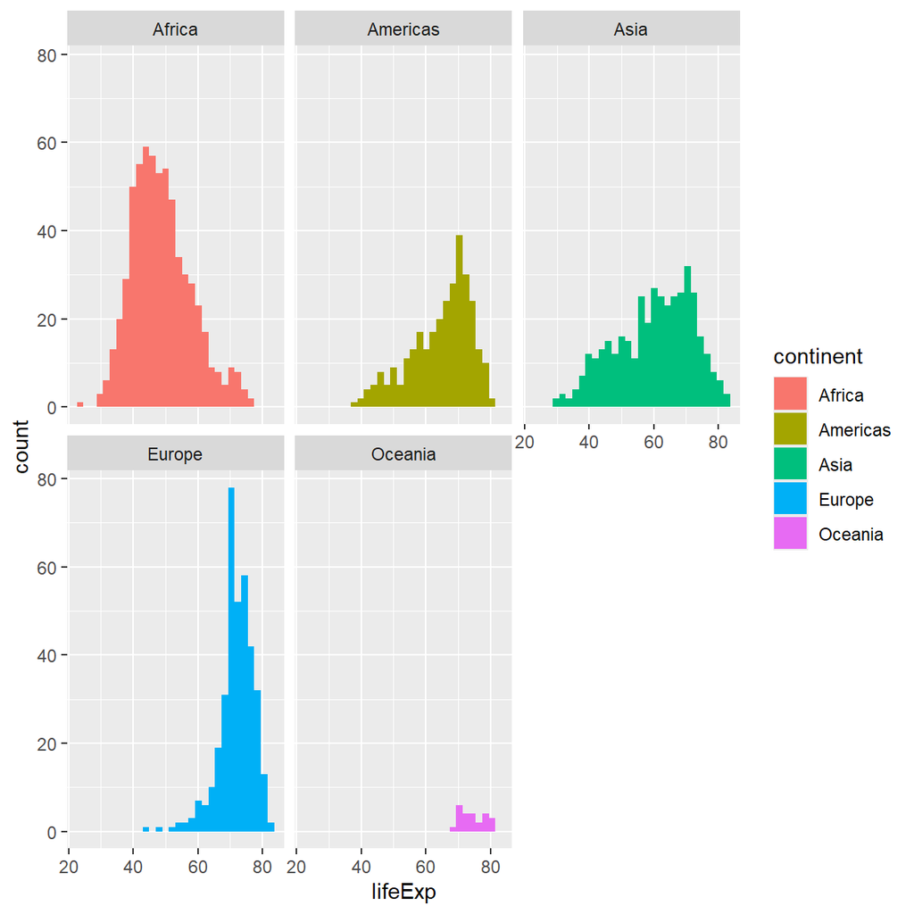

## So many other geoms

Check out:

- [ggplot2 cheatsheet](https://ggplot2.tidyverse.org/#cheatsheet)
- [ggplot2 cookbook](https://r-graphics.org/)
- [ggplot2 tutorial](https://www.cedricscherer.com/2019/08/05/a-ggplot2-tutorial-for-beautiful-plotting-in-r/)

## Summary: The ggplot skeleton

Every ggplot has the same basic structure:

```r
ggplot(
  data,
  aes(x = ..., y = ..., color = ...)
) +
  geom_xxx()
```

- `ggplot()`: initialize the plot with data and aesthetic mappings
- `aes()`: map variables to visual properties (x-axis, y-axis, color, shape, size, …)
- `geom_xxx()`: define how data points are drawn
- Layers are connected with `+`

# Now you

Task 1 (35 min)

Exploratory data analysis with the penguin data set

**Find the task description [here](https://selinazitrone.github.io/intro-r-data-analysis/sessions/tasks/ggplot-task-1.html)**

# Beautifying plots

> From default to publication-ready

## Mapping vs. setting aesthetics

Inside `aes()`: **map** a variable to color

[figure not shown]

```r
ggplot(
  gapminder_2007,
  aes(
    x = gdpPercap,
    y = lifeExp,
    color = continent
  )
) +
  geom_point()
```

Inside `geom`: **set** color of all points

[figure not shown]

```r
ggplot(
  gapminder_2007,
  aes(
    x = gdpPercap,
    y = lifeExp
  )
) +
  geom_point(
    color = "steelblue"
  )
```

## Mapping vs. setting aesthetics

You can change point shape, size, and transparency in the same way:

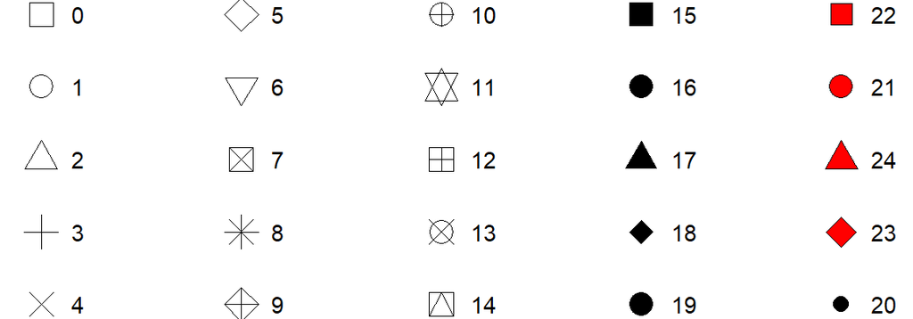

```r
ggplot(
  gapminder_2007,
  aes(
    x = gdpPercap,
    y = lifeExp
  )
) +
  geom_point(
    size = 3, # size
    shape = 17, # shape
    color = "steelblue", # color
    alpha = 0.5 # transparency (0-1)
  ) +
  scale_x_log10()
```

[Shape](http://www.cookbook-r.com/Graphs/Shapes_and_line_types/) and [color](https://derekogle.com/NCGraphing/resources/colors) codes

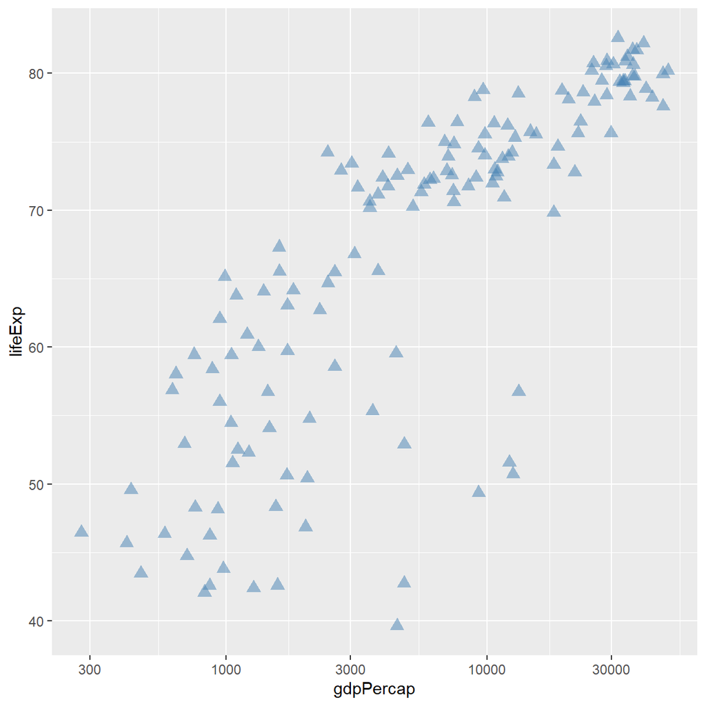

## Starting point

Let’s take this plot and make it look better step by step:

```r
my_plot <- ggplot(
  gapminder_2007,
  aes(
    x = gdpPercap,
    y = lifeExp,
    color = continent
  )
) +
  geom_point() +
  scale_x_log10()
my_plot
```

- Saving the plot in a variable `my_plot` so we can build on it
- Other plot layers can still be added to `my_plot`

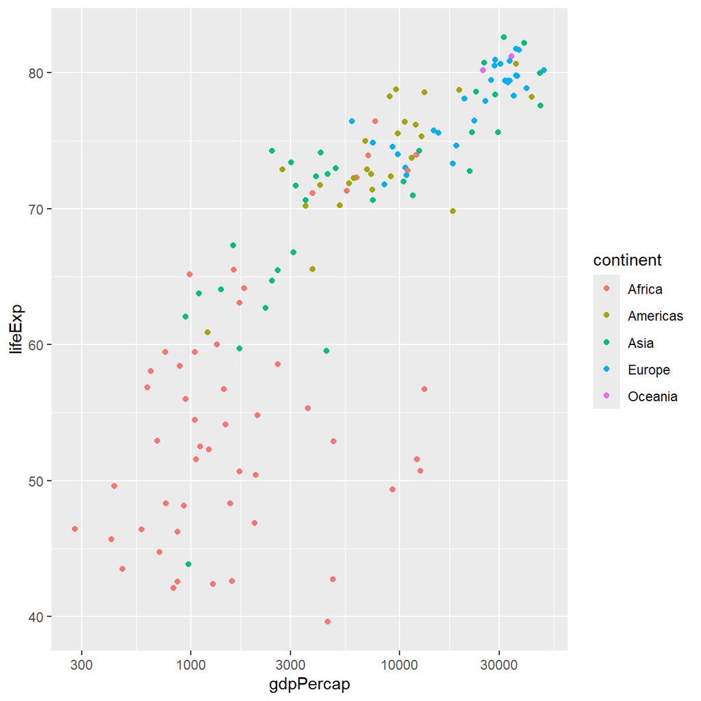

## `scale_color_manual()`: choose your own colors

Change the colors of the color aesthetic:

```r
my_plot <- my_plot +
  scale_color_manual(
    values = c(
      "darkorange",
      "steelblue",
      "forestgreen",
      "orchid",
      "grey70"
    )
  )
my_plot
```

- One color per group: number of colors must match the number of groups
- Colors can be [names](https://derekogle.com/NCGraphing/resources/colors) or hex codes like `"#FF6B35"`

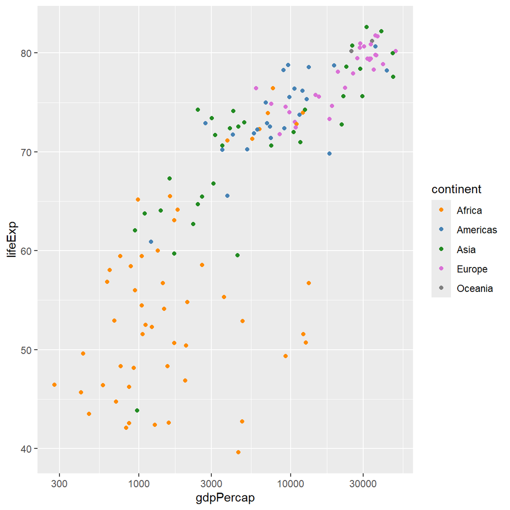

## `scale_color_viridis_d`

Change the colors of the color aesthetic:

```r
my_plot +
  scale_color_viridis_d()
```

- The viridis color palette is designed for viewers with common forms of color blindness
- `viridis_d` for discrete colors, `viridis_c` for continuous colors
- Other viridis palettes with the `option` argument: `"magma"`, `"inferno"`, `"plasma"`, `"cividis"`

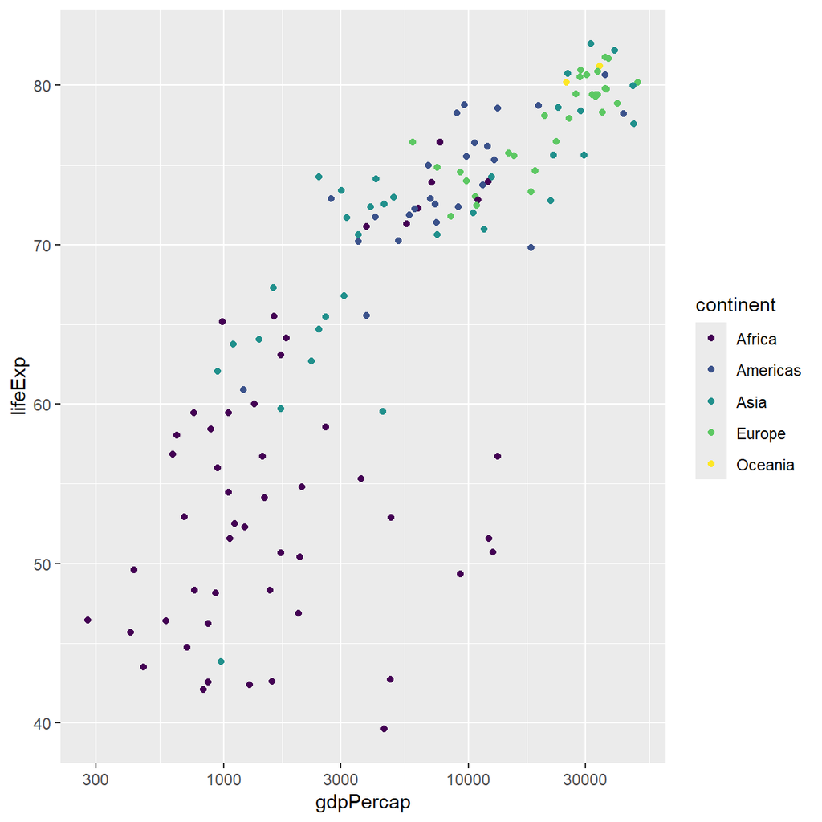

## `scale_color_brewer()`: use a color palette

```r
my_plot +
  scale_color_brewer(
    palette = "Set2"
  )
```

- Pre-defined palettes, many are colorblind-friendly
- Other options: `"Dark2"`, `"Paired"`, `"Pastel1"`, …
- Check `?scale_color_brewer` for all options

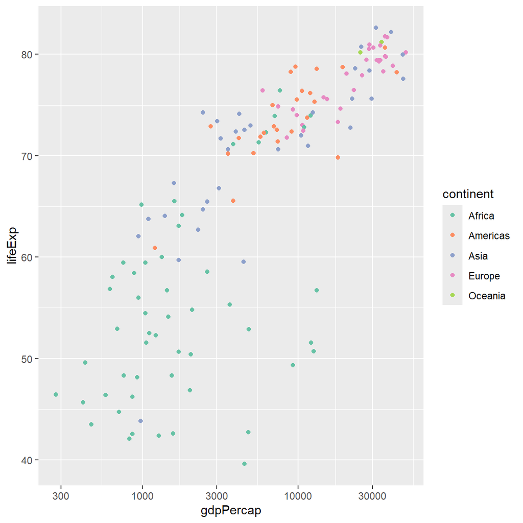

## So many color options

Many packages provide additional color palettes for ggplot:

- [ggsci](https://nanx.me/ggsci/): palettes inspired by scientific journals (e.g. Nature, Lancet) and sci-fi movies
- scico: scientific color palettes that are colorblind-friendly
- MetBrewer: palettes inspired by paintings from the Metropolitan Museum of Art
- NatParksPalettes: palettes inspired by photos of national parks from around the world
- [ggthemes](https://jrnold.github.io/ggthemes/): palettes and themes from e.g. The Economist, Tableau, Wall Street Journal
- [paletteer](https://emilhvitfeldt.github.io/paletteer/): one interface to thousands of palettes from many different packages

## `scale_fill_*` vs. `scale_color_*`

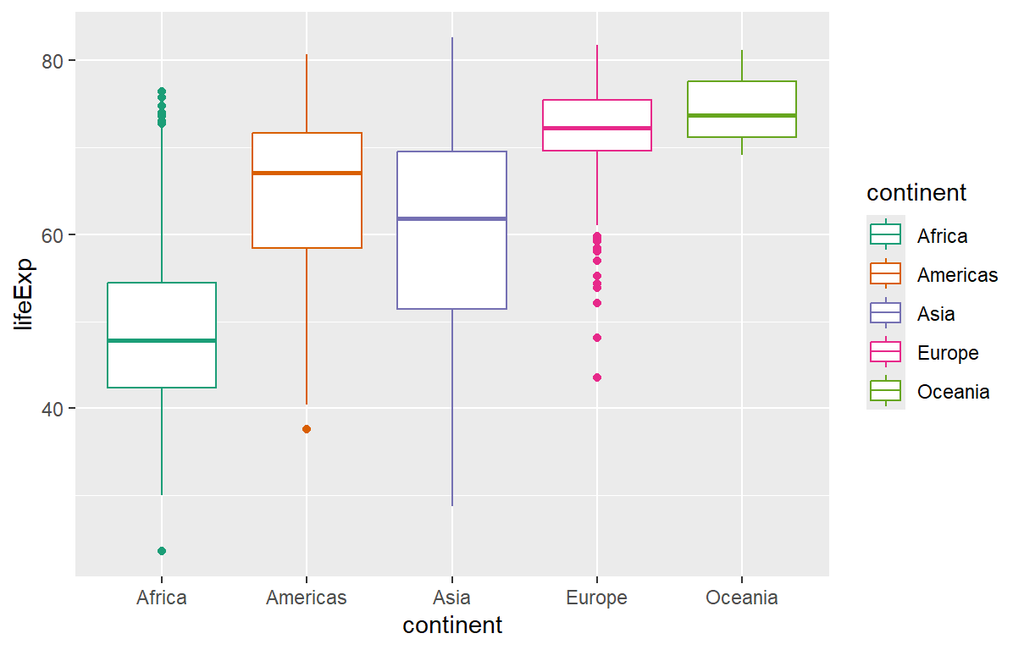

```r
ggplot(
  gapminder,
  aes(
    x = continent,
    y = lifeExp,
    color = continent
  )
) +
  geom_boxplot() +
  scale_color_brewer(
    palette = "Dark2"
  )
```

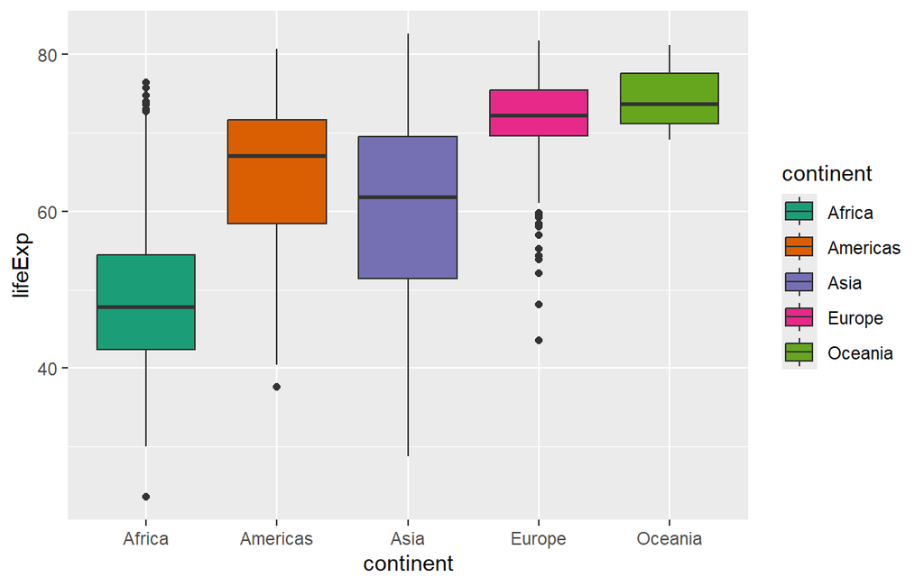

```r
ggplot(
  gapminder,
  aes(
    x = continent,
    y = lifeExp,
    fill = continent
  )
) +
  geom_boxplot() +
  scale_fill_brewer(
    palette = "Dark2"
  )
```

## `labs`: Change axis and legend titles and add plot title

```r
my_plot <- my_plot +
  labs(
    x = "GDP per capita [US$]",
    y = "Life expectancy [years]",
    color = "Continent",
    title = "Wealth and life expectancy",
    subtitle = "Higher GDP per capita is associated with longer life expectancy",
    caption = "Data from the gapminder package"
  )
my_plot
```